# Final_Qichao_Huang

## Problem1

### Two factor ho lee model

\begin{equation} r(t) = x_1(t) + x_2(t) \\ dx_1(t) = \mu_1dt+\sigma_1dW_1(t) \\ dx_2(t) = \mu_2dt+\sigma_2dW_2(t) \\ dW_1(t)dW_2(t) = \rho dt \end{equation}

$L(t,T_1,T_2) = \frac{1}{T2-T1}(\frac{P(t,T1)}{P(t,T2)}-1)$

$ P(t,T) = E[e^{-\int_t^Tr(s)ds}] $

So we want to know the bond dynamics

\begin{equation} x_1(t) = x_1(0)+\int_0^t\mu_1ds+\sigma_1\int_0^tdW_1(s) = x_1(0)+\mu_1t+\sigma_1W_1(t) \\ x_2(t) = x_2(0)+\mu_2t+\sigma_2W_2(t) \\ r(t) = x_1(0)+x_2(0)+(\mu_1+\mu_2)t+\sigma_1W_1(t)+\sigma_2W_2(t) \\ r(T) = x_1(t)+x_2(t)+(\mu_1+\mu_2)(T-t)+\sigma_1(W_1(T)-W_1(t))+\sigma_2(W_2(T)-W_2(t)) \end{equation}

Lemma1: $\int_t^Tr(s)ds$ follows the normal distribution

Prove:

\begin{align} \int_t^Tr(s)ds &= Tr(T)-tr(t)-\int_t^Tsdr(s) \\ &= Tr(T)-tr(t)-\int_t^Ts((\mu1+\mu2)ds+\sigma_1dW_1(s)+\sigma_2dW_2(s)) \\ &= T(r(t)+(\mu_1+\mu_2)(T-t)+\sigma_1(W_1(T)-W_1(t))+\sigma_2(W_2(T)-W_2(t)))-tr(t)-\frac{1}{2}(T^2-t^2)(\mu1+\mu2)-\sigma_1\int_t^TsdW_1(s)-\sigma_2\int_t^TsdW_2(s) \\ &= \frac{1}{2}(T-t)^2(\mu1+\mu2)+(T-t)r(t)+\sigma_1\int_t^T(T-s)dW_1(s)+\sigma_2\int_t^T(T-s)dW_2(s) \end{align}

The sum of joint normal two random variables is normal.

\begin{align} M = E(\int_t^Tr(s)ds) &= \frac{1}{2}(T-t)^2(\mu1+\mu2)+(T-t)r(t)\\ V = Var(\int_t^Tr(s)ds) &= \sigma_1^2\int_t^T(T-s)^2ds + \sigma_2^2\int_t^T(T-s)^2ds +2\rho \sigma_1\sigma_2\int_t^T(T-s)^2ds\\ &= \frac{1}{3}(T-t)^3(\sigma_1^2+\sigma_2^2+2\rho \sigma_1\sigma_2) \\ \mbox{The bond dynamcis are given by} \\ P(t,T) &= E[e^{-\int_t^Tr(s)ds}] \\ &= e^{-M+0.5V} \\ &= e^{-\frac{1}{2}(T^2-t^2)(\mu1+\mu2)-(T-t)r(t)+\frac{1}{6}(T-t)^3(\sigma_1^2+\sigma_2^2+2\rho \sigma_1\sigma_2)} \\ &= e^{-\frac{1}{2}(T^2-t^2)(\mu1+\mu2)+\frac{1}{6}(T-t)^3(\sigma_1^2+\sigma_2^2+2\rho \sigma_1\sigma_2)-(T-t)r(t)} \end{align}

Set \begin{align} A(t,T) &= -\frac{1}{2}(T-t)^2(\mu1+\mu2)+\frac{1}{6}(T-t)^3(\sigma_1^2+\sigma_2^2+2\rho \sigma_1\sigma_2) \ B(t,T) &= T-t \ P(t,T) &= e^{A(t,T)-B(t,T)r(t)} \end{align}

\begin{align} L(t,T_1,T_2) &= \frac{1}{T2-T1}(\frac{P(t,T1)}{P(t,T2)}-1) \\ &= \frac{1}{T2-T1}(\frac{e^{A(t,T1)-B(t,T1)r(t)}}{e^{A(t,T2)-B(t,T2)r(t)}}-1) \\ &= \frac{1}{T2-T1}(e^{(A(t,T1)-A(t,T2))-(B(t,T1)-B(t,T2))r(t)}-1) \\ \end{align}

r(t) follows the normal distribution \begin{align} M = E[(A(t,T1)-A(t,T2))-(B(t,T1)-B(t,T2))r(t)] &= (A(t,T1)-A(t,T2))-(B(t,T1)-B(t,T2))(r0+(\mu1+\mu2)t) \ V = Var((A(t,T1)-A(t,T2))-(B(t,T1)-B(t,T2))r(t)) &= (B(t,T1)-B(t,T2)^2(\sigma_1^2+\sigma_2^2+2\rho \sigma_1\sigma_2)t\ Futures(0,T1,T2) &= E^Q[L(t,T1,T2)] \ &= E^Q[\frac{1}{T2-T1}(e^{(A(t,T1)-A(t,T2))-(B(t,T1)-B(t,T2))r(t)}-1)] \ &= \frac{1}{T2-T1}(E^Q[e^{(A(t,T1)-A(t,T2))-(B(t,T1)-B(t,T2))r(t)}]-1) \ &= \frac{1}{T2-T1}(e^{M+0.5V}-1) \end{align}

\begin{align} Vol(L(t,T1,T2)) &= \frac{1}{\sqrt{t}}\sqrt{Var(L(t,T1,T2)} \\ &= \frac{1}{\sqrt{t}*(T2-T1)}\sqrt{E(e^{2*(A(t,T1)-A(t,T2))-(B(t,T1)-B(t,T2))r(t)})-E(e^{(A(t,T1)-A(t,T2))-(B(t,T1)-B(t,T2))r(t)})} \\ &= \frac{1}{\sqrt{t}*(T2-T1)}\sqrt{e^{2M+2V}-e^{2M+V}} \end{align}

### 2 calibrate the model parameter

$\alpha = \{\mu_1,\mu_2,\sigma_1,\sigma_2,x_1(0),x_2(0)\}$

```python
import numpy as np
import pandas as pd
import datetime
from scipy.optimize import leastsq
from scipy import optimize
import matplotlib.pyplot as plt
%matplotlib inline
import numdifftools as nd
```

```python
def A(t,T,para):
    mu1,mu2,sig1,sig2,rho = para
    return -0.5*(T-t)**2*(mu1+mu2)+1./6*(T-t)**3*(sig1**2+sig2**2+2*rho*sig1*sig2)

def B(t,T):
    return T-t

def mean_r(t,r0,para,dist = 'Q'):
    mu1,mu2,sig1,sig2,rho = para
    m = r0+(mu1+mu2)*t
    if (dist == 'F'):
        m -= (sig1**2+sig2**2+2*rho*sig1*sig2) * pow(t,2)*0.5
    return m

#3 para
def var_r(t,T,r0,para):
    sig1,sig2,rho = para
    return (sig1**2+sig2**2+2*rho*sig1*sig2)*(T-t)

def zero_bond(t,T,r_t0,para):
    return np.exp(A(t,T,para)-B(t,T,para)*r_t0)

def fwd_rate(t,T1,T2,r0,para,dist = 'Q'):
    mu1,mu2,sig1,sig2,rho = para
    m = (A(t,T1,para)-A(t,T2,para))-(B(t,T1)-B(t,T2))*mean_r(t,r0,para,dist)
    v = var_r(0,t,r0,para[2:])*(B(t,T1)-B(t,T2))**2
    return 1./0.25*(np.exp(m+v/2.)-1)

#moment generation function is exp(tm+0.5sig^2t^2)
def mgf(t,T1,T2,r0,para,k,dist = 'Q'):
    A_diff = A(t,T1,para) - A(t,T2,para)
    B_diff = B(t,T1) - B(t,T2)
    m = A_diff - B_diff * mean_r(t,r0,para,dist)
    v = var_r(0,t,r0,para[2:])*(B(t,T1)-B(t,T2))**2
    return np.exp(k*(2*m+k*v)/2.)

def fwd_rate_mean(t,T1,T2,r0,para,dist='Q',acrual=0.25):
    m1 = mgf(t,T1,T2,r0,para,1,dist)
    return 1/acrual*(m1-1)

def fwd_rate_sig(t,T1,T2,r0,para,dist='Q',acrual=0.25):
    m2 = mgf(t,T1,T2,r0,para,2,dist)
    m1 = mgf(t,T1,T2,r0,para,1,dist)
    e2 = m2 - m1**2
    return 1/acrual*pow(e2,0.5)

def error_function(para,dist = 'Q'):
    tmp_para = para
    r0=0.01
    x = np.array([fwd_rate(t1,t1,t1+0.25,r0,tmp_para,dist ) for t1 in expire_list])
    return x-future_rate

def error_function_ridge(para,Lambda = 1.0,dist = 'Q'):
    tmp_para = np.array(para)
    r0=0.01
    x = np.array([fwd_rate(t1,t1,t1+0.25,r0,tmp_para,dist) for t1 in expire_list])
    return np.sum((x-future_rate)**2)+0.5*Lambda*np.sum(tmp_para**2)

def cal_Jacobian(func,p0,epsilon):
    return optimize.approx_fprime(np.array(p0),func,epsilon)

def fun_jacobian (p0,func,**kwargs):
    out=[]
    #return cal_Jacobian(error_function,p0)
    res = func(p0,**kwargs)
    return nd.Gradient(func)(p0)

#THE jacabian function
def error_fun_jacobian (p0,dist='Q'):
    res = error_function(p0,dist)
    out = []
    for i in range(len(res)):
        f = lambda p0:error_function(p0,dist)[i]
        out.append(optimize.approx_fprime(p0,f,1e-6))
    return np.array(out)

def cal_Jacobian_cond(J):
    return np.linalg.cond(np.dot(J.T,J))
```

```python
expiry = (datetime.datetime(2017,6,21)-datetime.datetime(2017,4,4)).days/360.0
expire_list = 0.25*np.arange(0,20)+expiry
print "expiry \n",expire_list
y = "1.285 1.425 1.52 1.61 1.72 1.825 1.94 2.01 2.08 2.145 2.225 2.27 2.325 2.37 2.43 2.465 2.505 2.55 2.6 2.635"
future_rate = np.array(map(float,y.split(" ")))/100
print "\n future rate \n",future_rate
```

```
expiry
[ 0.21666667  0.46666667  0.71666667  0.96666667  1.21666667  1.46666667
  1.71666667  1.96666667  2.21666667  2.46666667  2.71666667  2.96666667
  3.21666667  3.46666667  3.71666667  3.96666667  4.21666667  4.46666667
  4.71666667  4.96666667]

 future rate
[ 0.01285  0.01425  0.0152   0.0161   0.0172   0.01825  0.0194   0.0201
  0.0208   0.02145  0.02225  0.0227   0.02325  0.0237   0.0243   0.02465
  0.02505  0.0255   0.026    0.02635]
```

```
mu1 : 0.0128366415643
mu2 : -0.00716335923019
sig1 : 0.0572389014107
sig2 : 0.0648313336511
rho : -0.855550352871
```

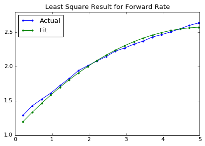

```python
#treat as forward rater
r0 =0.01
para_list_str = ["mu1","mu2","sig1","sig2","rho","r0"]

optimize_res = leastsq(error_function,x0=(0.01,-0.01,0.05,0.05,0.5),
                       Dfun = error_fun_jacobian,args = ('F'),
                       full_output=1)
para_list = optimize_res[0]
for x,y in zip(para_list_str,para_list):
    print x,":",y
optimize_future_rate = np.array([fwd_rate(t1,t1,t1+0.25,r0,para_list,dist = 'F') for t1 in expire_list])
plt.plot(expire_list,future_rate*100,".-",
         expire_list,optimize_future_rate*100,".-")
plt.legend(["Actual","Fit"],loc='best')
plt.title("Least Square Result for Forward Rate");
```

```python
Jacob = np.matrix(fun_jacobian(para_list,error_function,dist='F'))
eig_value,eig_vector = np.linalg.eig(Jacob.T*Jacob)
print "condition number",eig_value[0]/eig_value[-1]
```

```
condition number -2.90346280821e+23
```

```python
def my_pca(cov,num):
    xcv,vcv=np.linalg.eig(cov)
    pca_factor=data.dot(vcv[:,:num])
    return xcv,vcv[:,:num],pca_factor

def Simple_PCA_Reduction(p0,y,Lambda,factor_num,tol=1e-6,maxIter = 500,dist = 'Q'):
    count=0
    for i in range(maxIter):
        J = error_fun_jacobian(p0)
        #print "J",J
        H  = np.dot(J.T,J)
        cov = np.cov(J.T)
        xcv,vcv = np.linalg.eig(cov)
        J_pca = np.dot(J,vcv[:,:factor_num])
        p_pca = np.dot(p0,vcv[:,:factor_num])
        e = y-error_function(p0,dist)
        p1_pca = np.linalg.inv(np.dot(J_pca.T,J_pca)+Lambda*np.eye(factor_num)).dot(J_pca.T.dot(e))
        p0 = np.dot(vcv[:,:factor_num],p1_pca)
        print "p0",p0
        if np.sum((error_function(p0)-y)**2)<tol:
            print "Success"
            return p0
    return p0

def Simple_Ridge_Regression(p0,y,Lambda,tol=1e-6,maxIter = 500,dist = 'Q'):
    for i in range(maxIter):
        J = error_fun_jacobian(p0)
        H  = np.dot(J.T,J)
        e = y-error_function(p0,dist)
        p0 = np.linalg.inv(np.dot(J.T,J)+Lambda*np.eye(J.shape[1])).dot(J.T.dot(e))
        if np.sum((error_function(p0)-y)**2)<tol:
            print "Success"
            return p0
    return p0
```

```python
#Simple_PCA_Reduction(p0,future_rate,0.0,2,dist='F')
p0 = np.array([0.03,-0.01,0.05,0.05,0.5])
p1 = Simple_Ridge_Regression(p0,future_rate,0.01,1e-6,maxIter = 100,dist = 'F')
Jacob = np.matrix(fun_jacobian(p1,error_function,dist='F'))
eig_value,eig_vector = np.linalg.eig(Jacob.T*Jacob)
print "condition number",eig_value
```

```
condition number [  0.00000000e+00   3.87055549e+02   4.82762909e-16   4.02750977e-28
   0.00000000e+00]
```

```python
Jacob = np.matrix(optimize_res[2]['fjac'].T)
eig_value,eig_vector = np.linalg.eig(Jacob.T*Jacob)
print "the condition number is",eig_value[0]/eig_value[-1]
eig_value
```

```
the condition number is 1383.42606193
```

```
array([  5.03878959e+02,   7.36509017e+01,   1.27879640e+00,
         1.00332909e+00,   3.64225435e-01])
```

```
the parameter is:  [  1.86505206e-03   1.86505168e-03  -2.87435468e-08  -2.87442263e-08
   1.20378940e-08]
```

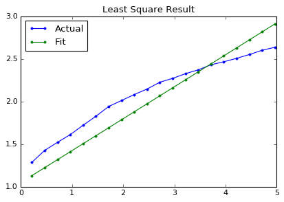

```python
#use the minimize and change the objective function with penalty
from scipy.optimize import minimize
res = minimize(error_function_ridge,x0=(0.01,-0.01,0.05,0.05,0.5),args=(1,'F'))
x = res.x
print "the parameter is: ",x
optimize_future_rate_1 = np.array([fwd_rate(t1,t1,t1+0.25,r0,x,dist = 'F') for t1 in expire_list])
plt.plot(expire_list,future_rate*100,".-",
         expire_list,optimize_future_rate_1*100,".-")
plt.legend(["Actual","Fit"],loc='best')
plt.title("Least Square Result");
```

```python
Jacob = np.matrix(fun_jacobian(x,error_function,dist='F'))
eig_value,eig_vector = np.linalg.eig(Jacob.T*Jacob)
eig_value
```

```
array([  3.83016440e+02,   0.00000000e+00,   1.98520200e-17,
         3.28085756e-26,   0.00000000e+00])
```

You could see that using our jacobian matrix, it is slow and do not get a good result. So it's better use the kacobian in the package.

Basically, all the volatility and correlation is so small that the model degenerates to a constant rate model.

$$y_t(\tau)=\beta_{1t}+\beta_{2t}(\frac{1-e^{-\lambda\tau}}{\lambda\tau})+ \beta_{3t}(\frac{1-e^{-\lambda\tau}}{\lambda\tau}-e^{-\lambda\tau})$$

### 3 DNS

```
the beta coef is [ 0.03518402 -0.02358604 -0.00028638] condition number is: 52.1961174572
So there is no need to use the ridge regression or PCA reduction
```

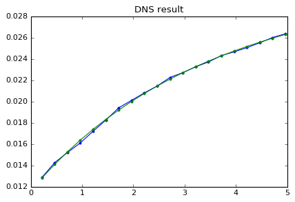

```python
Lambda = 0.492
time_lam = expire_list*Lambda
X=np.array([[1.,(1-np.exp(-tmp))/tmp,(1-np.exp(-tmp))/tmp-np.exp(-tmp)] for tmp in time_lam])

def Ridge_Regression(x,y,Lambda):
    tmp1 = np.linalg.inv(np.dot(x.T,x)+Lambda*np.eye(x.shape[1]))
    tmp2 = np.dot(x.T,y)
    beta = np.dot(tmp1,tmp2)
    eig,vec = np.linalg.eig(tmp1)
    return beta,eig[0]/eig[-1]

res = Ridge_Regression(X,future_rate,0.000)
print "the beta coef is",res[0],\
"condition number is:",res[1],\
"\nSo there is no need to use the ridge regression or PCA reduction"
plt.plot(expire_list,future_rate,'.-',expire_list,np.dot(X,res[0]),'.-');
plt.title("DNS result");
```

```python
vol = pd.read_csv("Final_CM_ED_Vol.csv",header=None,index_col=[0],names=["Index","Vol"])
vol["Maturity"] = np.arange(1,20)*0.25
vol['Vol'] = vol['Vol']/100
vol.set_index('Maturity',inplace=True)
vol
```

| Maturity | Vol |
| --- | --- |
| 0.25 | 0.017831 |
| 0.50 | 0.023286 |
| 0.75 | 0.028577 |
| 1.00 | 0.033450 |
| 1.25 | 0.037477 |
| 1.50 | 0.040836 |
| 1.75 | 0.043592 |
| 2.00 | 0.046160 |
| 2.25 | 0.048212 |
| 2.50 | 0.049891 |
| 2.75 | 0.051133 |
| 3.00 | 0.052076 |
| 3.25 | 0.052507 |
| 3.50 | 0.052914 |
| 3.75 | 0.052679 |
| 4.00 | 0.052506 |
| 4.25 | 0.052489 |
| 4.50 | 0.052430 |
| 4.75 | 0.052260 |

```
parameter is: [ 0.22646656 -0.59213106  0.04641405  0.04641405 -0.65373376]
```

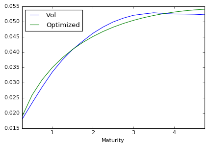

```python
def error_function_vol(para,dist = 'Q'):
    tmp_para = para
    r0=0.01
    x = [fwd_rate_sig(T1,T1,T1+0.25,r0,tmp_para,dist,acrual=0.25) for T1 in np.arange(1,20)*0.25]
    y = vol['Vol'].as_matrix()
    return x-y

res = leastsq(error_function_vol,x0=(0.05,-0.01,0.05,0.05,0.5),args='Q',ftol=1e-9,full_output=1)

vol['Optimized'] = [fwd_rate_sig(T1,T1,T1+0.25,0.01,res[0],'Q',acrual=0.25) for T1 in np.arange(1,20)*0.25]
vol.loc[:,['Vol','Optimized']].plot()
print "parameter is:",res[0]
```

```python
Jacob = np.matrix(res[2]['fjac'].T)
eig_value,eig_vector = np.linalg.eig(Jacob.T*Jacob)
print "the condition number is",eig_value[0]/eig_value[-1]
```

```
the condition number is 106.22287137
```

We could see that the condition number is less than 1000. So we don't need to use the ridge regression.

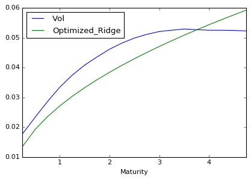

```python
def error_function_vol_square(para,Lambda,dist = 'Q'):
    tmp_para = para
    r0=0.01
    x = [fwd_rate_sig(T1,T1,T1+0.25,r0,tmp_para,dist,acrual=0.25) for T1 in np.arange(1,20)*0.25]
    y = vol['Vol'].as_matrix()
    return np.sum((x-y)**2)+0.5*Lambda*np.sum(tmp_para**2)

bnds = ((0,0.5),(-0.5,0.5),(0,0.7),(0,0.7),(-1,1))
res = minimize(error_function_vol_square,x0=(0.03,-0.01,0.05,0.05,-0.5),args=5)#,bounds=bnds)

vol['Optimized_Ridge'] = [fwd_rate_sig(T1,T1,T1+0.25,0.01,res.x,'Q',acrual=0.25) for T1 in np.arange(1,20)*0.25]
vol.loc[:,['Vol','Optimized_Ridge']].plot()

#[fwd_rate_sig(T1,T1,T1+0.25,0.01,res.x,'Q',acrual=0.25) for T1 in np.arange(1,20)*0.25]
```

```python
Jacob = fun_jacobian(res.x,error_function_vol)
eig_value,eig_vector = np.linalg.eig(np.dot(Jacob.T,Jacob))
print "condition number",eig_value[0]/eig_value[-1]
```

```
condition number 1.99066950155e+19
```

We can see that the effect of ridge regression in this setting is limited.

### 6 Joint Fit

```python
p0 = np.array([0.03,-0.01,0.03,0.03,-0.5])
para_str = ["mu1","mu2","sig1","sig2","rho"]
for str_,tmp1,tmp2 in zip(para_str,fun_jacobian(p0,error_function).mean(axis=0),
                         fun_jacobian(p0,error_function_vol).mean(axis=0)):
    print str_,"sensitivity to rate is",tmp1,"sensitivity to vol is",tmp2
```

```
mu1 sensitivity to rate is 2.77159967648 sensitivity to vol is 0.0352549365675
mu2 sensitivity to rate is 2.77159967648 sensitivity to vol is 0.0352549365674
sig1 sensitivity to rate is 0.0095995052265 sensitivity to vol is 0.766359454343
sig2 sensitivity to rate is 0.0095995052265 sensitivity to vol is 0.766359454343
rho sensitivity to rate is 0.000575970313596 sensitivity to vol is 0.0459815672606
```

```python
def joint_fit(func1,func2,p0,tol = 1e-8,maxIter = 1000,**kwargs):
    mu1,mu2,sig1,sig2,rho = p0
    p0 = np.array(p0)
    f = lambda x:func1((x[0],x[1],sig1,sig2,rho),dist = 'F')
    g = lambda x:func2((mu1,mu2,x[0],x[1],x[2]),dist='F')
    for i in range(maxIter):
        sig1,sig2,rho = leastsq(g,x0=(sig1,sig2,rho))[0]
        mu1,mu2 = leastsq(f,x0=[mu1,mu2])[0]
        #print mu1,mu2,sig1,sig2,rho
        p1 = np.array([mu1,mu2,sig1,sig2,rho])
        if np.sum((p1-p0)**2)<tol:
            print "Success"
            return p1
        else:
            i+=1
            p0 = p1
    print "Fail to converge"
    return p1
```

```
Success
[ 0.17745887 -0.17233598  0.03351719  0.02958751 -0.59995792]
```

[figure not shown]

```python
p_last = joint_fit(error_function,error_function_vol,p0)
print p_last
optimize_future_rate = np.array([fwd_rate(t1,t1,t1+0.25,r0,p_last,dist = 'F') for t1 in expire_list])

fig,ax = plt.subplots(2,figsize=(12,8))
ax[0].plot(expire_list,future_rate*100,".-",
         expire_list,optimize_future_rate*100,".-")
ax[0].legend(["Actual","Fit"],loc='best')
ax[0].set_title("Forwards Rate");

optimize_vol = np.array([fwd_rate_sig(t1,t1,t1+0.25,r0,p_last,dist = 'F') for t1 in np.arange(1,20)*0.25])
# vol['Optimized'] = [fwd_rate_sig(T1,T1,T1+0.25,0.01,res[0],'Q',acrual=0.25) for T1 in np.arange(1,20)*0.25]
# vol.loc[:,['Vol','Optimized']].plot()
# print "parameter is:",res[0]
ax[1].plot(np.arange(1,20)*0.25,optimize_vol,'.-',np.arange(1,20)*0.25,vol['Vol'],'.-')
ax[1].legend(["Actual","Fit"],loc='best')
ax[1].set_title("Volatility");
```

### 7 Analyze the Result

1. I derive and implement the two factor Ho Lee model for the futures rate.
2. We model the TSM model and calibrate the parameter. Then I found that the condition number is large for the hessian matrix. It seems to be close to singular matrix because the sig1,sig2 and rho has little effect to the futures rate. In this part, I used the forward rates instead, because the futures rate in our model is always a straight line. We use a simple ridge regression to deal with the collinearity. Unfortunately, it has little effect on the model. (for the futures rate, it should minus **0.5**($\sigma_1^2+\sigma_2^2+2\rho\sigma_1\sigma_2$)
3. We use the DNS model to fit the rate. It fits well and with no collinearity problem.
4. We derive the model for the volatility.
5. We use the least square to find the parameter. The model is really sensitive to the initial value. There is less collinearity than the rate.
6. We use joint fit to fit the model. The mean parameter have more influence on the rate and the volatility and correlation parameter have more influence on the volatility side.
7. There are several questions. It seems to me that when I calculate the Jacobian matrix, the condition number for the Hessian matrix is always so large. So I cannot decide whether the PCA or Ridge have solved the collinearity.